# Bias Calculations of the Thesis Experiments

# Re-look at the Ungrammaticality Assymetry

- Obviously, I failed to introduce any bias in any of the experiments.
- Two questions to ask:
  - There is a clear difference between two experiments. Is this difference only about sampling?
  - Even though introducing a bias failed, there are still people who were biased (either towards grammatical or ungrammatical) regardless of our experiment.
- These subgroups of participants should behave according to the predictions.
- What are the predictions?
  - RT-wise: Faster RTs in ungrammatical conditions.
  - Response-wise: Ungrammaticality Effects, that is a substantial difference between grammatical-sg attractor and grammatical-pl attractor conditions.

# Descriptive Stats

## Mean Acceptable Responses

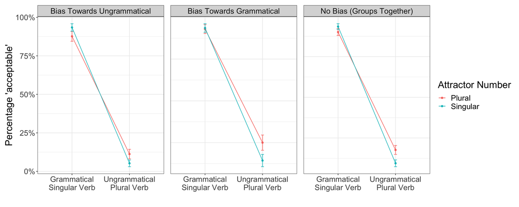

## Mean Reading Times of Correct Responses

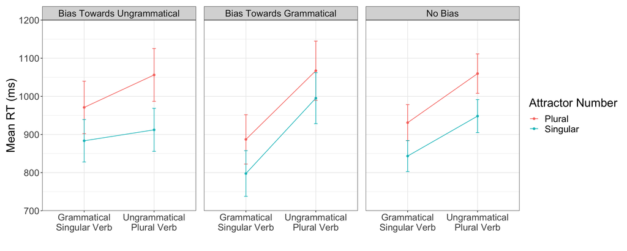